# Schrute Paper

Annual Central region summary

May 12, 2022

# 1 Schrute Paper Central region annual summary

## 1.1 Industry and Schrute summary

We are Schrute Paper, the foremost purveyor of fine paper and paper accessories. At Schrute Paper, a Scranton, PA-based family-owned business since 1945, we search the world over for paper products from nitrogen-rich soils and bring those products to our customers with a zero-downtime guarantee.

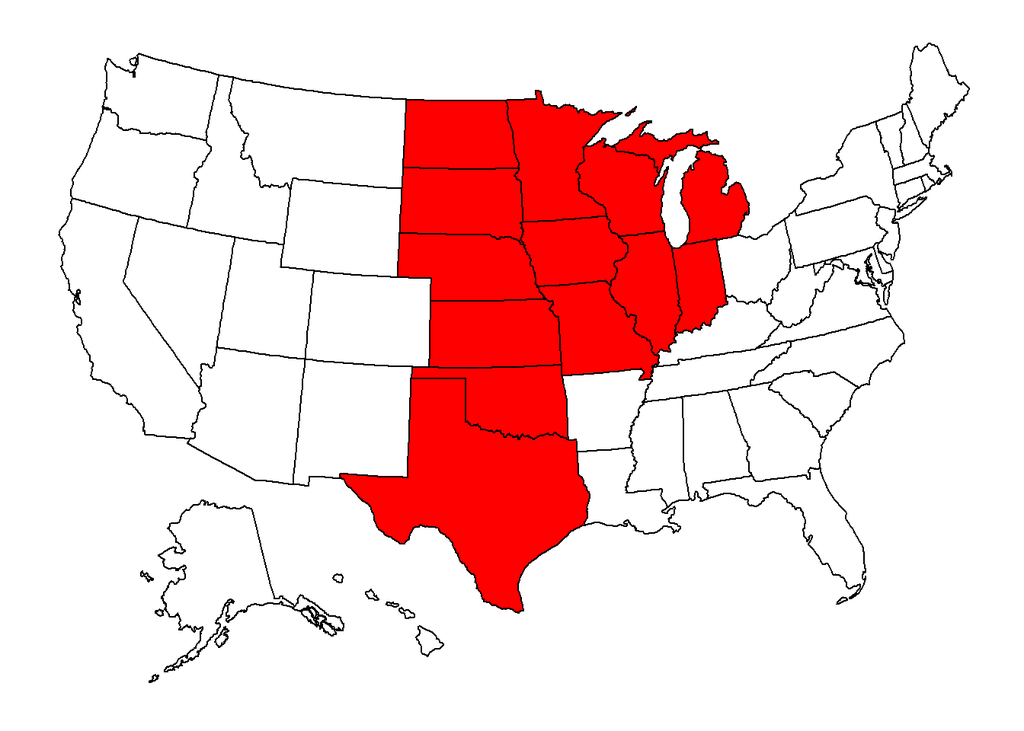

Figure 1.1: Schrute Central region map.

## 1.2 Schrute Paper Central region financial summary

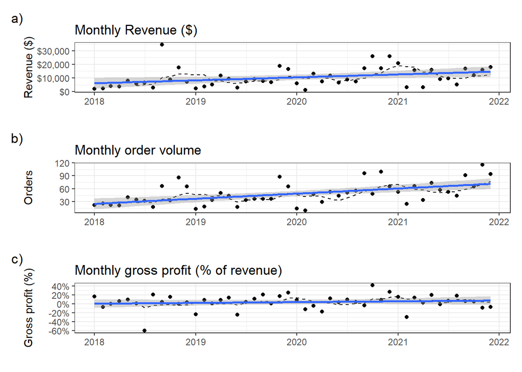

Figure 1.2: Sales trends for Schrute Paper Central . Black points are monthly totals. The solid blue trendline is the simple (ordinary least squares) linear regression model of monthly averages. The gray band around the blue trendline shows the 95% confidence interval around model mean predictions. The dashed black line is the six-month moving average of monthly averages.

Schrute Paper Central’s business is seasonal. Historically, our 4 month busy season, September through December, accounted for 51% of orders and 53% of revenue (Figure 1.2 a and b).

Schrute Paper Central’s business grown over time. Since 2018, monthly mean revenue increased from $6,230 to $14,662. Monthly order volume matched this trend and increased from 25 orders in January 2018 to 72 orders in December 2021. Since 2018, monthly gross profit (as a percentage of revenue) increased from 0% to 7% (Figure 1.2 c).

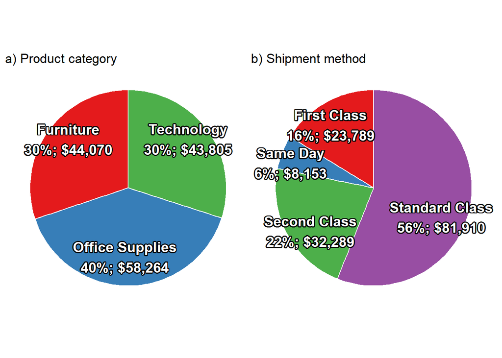

Figure 1.3: Schrute Central region 2021 revenue by product category and shipment method.

Schrute Paper Central’s 2021 revenue was not evenly distributed among product categories. Office Supplies contributed the most revenue at 40% whereas Technology contributed the least revenue at 30% (Figure 1.3 a).

Schrute Paper Central’s 2021 revenue was not evenly distributed among shipment methods. Orders that shipped via Standard Class contributed the most revenue at 56% whereas orders that moved via Same Day contributed the least revenue at 6% (Figure 1.3 b).

*Table 1. Three largest profit and loss centers for Schrute Paper Central in 2021.*

Central region profit and cost centers

2021

| Customer | Per order Revenue | Per order Gross profit ($) | Per order Gross profit (%) | Annual totals Revenue | Annual totals Gross profit ($) | Annual totals Gross profit (%) | Annual totals Order Volume |
| --- | --- | --- | --- | --- | --- | --- | --- |
| Three largest cost centers |  |  |  |  |  |  |  |
| Henry Goldwyn | $1,890 | −$2,929 | −155% | $1,890 | −$2,929 | −155% | 1 |
| Nathan Cano | $576 | −$777 | −135% | $1,729 | −$2,330 | −135% | 3 |
| Skye Norling | $763 | −$1,144 | −150% | $763 | −$1,144 | −150% | 1 |
| Three largest profit centers |  |  |  |  |  |  |  |
| Andy Reiter | $1,934 | $867 | 45% | $5,803 | $2,602 | 45% | 3 |
| Helen Wasserman | $665 | $158 | 24% | $5,322 | $1,261 | 24% | 8 |
| Bill Eplett | $1,160 | $411 | 35% | $3,481 | $1,234 | 35% | 3 |

Schrute Paper Central’s 3 largest cost centers produced a loss of $6,404 in 2021 (Table 1). Henry Goldwyn accounted for $-2,929 or 46% of this loss. Henry Goldwyn’s orders produced an average loss of $-2,929 and -155%.

Schrute Paper Central’s 3 largest profit centers earned the region a profit of $5,097 in 2021 (Table 1). Andy Reiter accounted for $2,602 or 51% of this profit. Andy Reiter’s orders produced an average profit of $867 and 45%.